# WRF Output EDA

Renata Poulton Kamakura

2025-04-23

##Read in data

To calculate wind speed from u and v components:

https://confluence.ecmwf.int/pages/viewpage.action?pageId=133262398

Should be the square root of u2 + v2

```r
#basic wrfoutput data
HourlyMeans16_0 <- read.csv("../../03ProcessedData/HourlyMeans_2016_0.csv")
HourlyMeans16_1 <- read.csv("../../03ProcessedData/HourlyMeans_2016_1.csv")
HourlyMeans16_2 <- read.csv("../../03ProcessedData/HourlyMeans_2016_2.csv")

HourlyMeans17_0 <- read.csv("../../03ProcessedData/HourlyMeans_2017_0.csv")
HourlyMeans17_1 <- read.csv("../../03ProcessedData/HourlyMeans_2017_1.csv")
HourlyMeans17_2 <- read.csv("../../03ProcessedData/HourlyMeans_2017_1.csv")

#to simplify the land use types
LU_names = c('Evergreen Needleleaf Forest', 'Evergreen Broadleaf Forest',
            'Deciduous Needleleaf Forest', 'Deciduous Broadleaf Forest',
            'Mixed Forests', 'Closed Shrublands',  'Open Shrublands',
            'Woody Savannas', 'Savannas', 'Grasslands',
            'Permanent wetlands', 'Croplands', 'Urban and Built-Up',
            'cropland/natural vegetation mosaic',
            'Snow and Ice', 'Barren or Sparsely Vegetated', 'Water')

NewLUs <- c('Forest', 'Forest', 'Forest', 'Forest', 'Forest',
            'Shrub/Savanna', 'Shrub/Savanna', 'Shrub/Savanna', 'Shrub/Savanna',
            "Shrub/Savanna", "Wetlands", "Crop", "Urban", "Crop", "Snow",
            "Barren", "Water")
NewLU_nums <- c(1,1,1,1,1,2,2,2,2,2,3,4,5,4,6,7,8)

LU_dict <- as.data.frame(matrix(0, nrow=17, ncol=4))
names(LU_dict) <- c("Original_Name", "Original_Num", "New_Name", "New_Num")

LU_dict$Original_Name <- LU_names
LU_dict$Original_Num <- 1:17
LU_dict$New_Name <- NewLUs
LU_dict$New_Num <- NewLU_nums

#distance from ocean pixels
Dists16 <- read.csv("../../03ProcessedData/Dist2Ocean_2016_0.csv")
Dists17 <- read.csv("../../03ProcessedData/Dist2Ocean_2017_0.csv")

##combine
HourlyMeans16_0$Dist2Ocean <- Dists16$Dist2Ocean[Dists16$lat == HourlyMeans16_0$lat & Dists16$long == HourlyMeans16_0$lon]
HourlyMeans16_1$Dist2Ocean <- Dists16$Dist2Ocean[Dists16$lat == HourlyMeans16_1$lat & Dists16$long == HourlyMeans16_1$lon]
HourlyMeans16_2$Dist2Ocean <- Dists16$Dist2Ocean[Dists16$lat == HourlyMeans16_2$lat & Dists16$long == HourlyMeans16_2$lon]
HourlyMeans17_0$Dist2Ocean <- Dists17$Dist2Ocean[Dists16$lat == HourlyMeans17_0$lat & Dists17$long == HourlyMeans17_0$lon]
HourlyMeans17_1$Dist2Ocean <- Dists17$Dist2Ocean[Dists16$lat == HourlyMeans17_1$lat & Dists17$long == HourlyMeans17_1$lon]
HourlyMeans17_2$Dist2Ocean <- Dists17$Dist2Ocean[Dists16$lat == HourlyMeans17_2$lat & Dists17$long == HourlyMeans17_2$lon]
#########change the hours to local time zone from UTC
HourDict <- as.data.frame(matrix(0, nrow=24, ncol=2))
names(HourDict) <- c("Current", "New")
HourDict$Current <- 0:23
HourDict$New <- c(18, 19, 20, 21, 22, 23, 0, 1, 2,
                  3, 4, 5, 6, 7, 8, 9, 10, 11, 12,
                  13, 14, 15, 16, 17)

#convert the hours to CST
HourlyMeans16_0$hour <- HourDict$New[HourlyMeans16_0$hour + 1]
HourlyMeans16_1$hour <- HourDict$New[HourlyMeans16_1$hour + 1]
HourlyMeans16_2$hour <- HourDict$New[HourlyMeans16_2$hour + 1]

HourlyMeans17_0$hour <- HourDict$New[HourlyMeans17_0$hour + 1]
HourlyMeans17_1$hour <- HourDict$New[HourlyMeans17_1$hour + 1]
HourlyMeans17_2$hour <- HourDict$New[HourlyMeans17_2$hour + 1]

#########modify land use
HourlyMeans16_0$landuse <- LU_dict$New_Name[HourlyMeans16_0$landuse]
HourlyMeans16_1$landuse <- LU_dict$New_Name[HourlyMeans16_1$landuse]
HourlyMeans16_2$landuse <- LU_dict$New_Name[HourlyMeans16_2$landuse]

HourlyMeans17_0$landuse <- LU_dict$New_Name[HourlyMeans17_0$landuse]
HourlyMeans17_1$landuse <- LU_dict$New_Name[HourlyMeans17_1$landuse]
HourlyMeans17_2$landuse <- LU_dict$New_Name[HourlyMeans17_2$landuse]

#for later work
focalHRS <- 8:21
```

```r
###############create new df with box labels
#2016
HourlyMeans16_0wb <- HourlyMeans16_0 %>%
  mutate(sim="sim1")

HourlyMeans16_1wb <- HourlyMeans16_1 %>%
  mutate(sim="sim2")

HourlyMeans16_2wb <- HourlyMeans16_2 %>%
  mutate(sim="sim3")

###2017
HourlyMeans17_0wb <- HourlyMeans17_0 %>%
  mutate(sim="sim1")

HourlyMeans17_1wb <- HourlyMeans17_1 %>%
  mutate(sim="sim2")

HourlyMeans17_2wb <- HourlyMeans17_2 %>%
  mutate(sim="sim3")
```

```r
#this is if you want to compare the dfs for the simulations versus the baseline for temperature, rh, slp, and wspd10

HourlyMeans16_wb <- bind_rows(HourlyMeans16_0wb, HourlyMeans16_1wb, HourlyMeans16_2wb)
HourlyMeans17_wb <- bind_rows(HourlyMeans17_0wb, HourlyMeans17_1wb, HourlyMeans17_2wb)

HourlyMeans16_wb_lo <- HourlyMeans16_wb %>% filter(landuse != "Water")
HourlyMeans17_wb_lo <- HourlyMeans17_wb %>% filter(landuse != "Water")
```

##Basic EDA

This section is meant to give us a background sense of whether our planned model set up is reasonable. In particular, we will look at differences across hours and across land use types here.

## Temperature

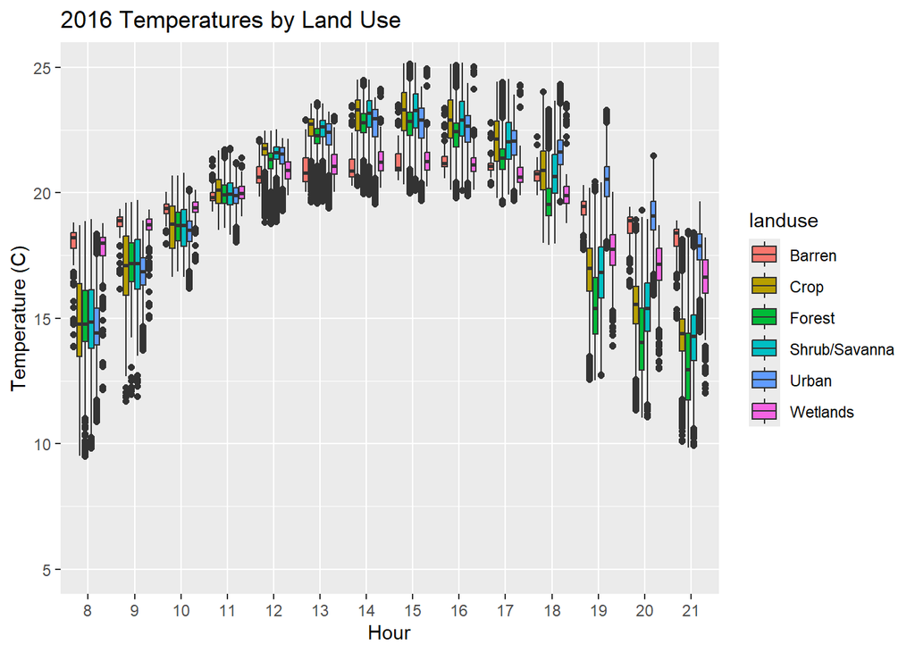

```r
############################temp and land use + hour
ggplot(HourlyMeans16_wb_lo[c(HourlyMeans16_wb_lo$hour %in% focalHRS),], aes(x=as.factor(hour), y=(T2-273.15), fill=landuse)) +
  geom_boxplot()  + ggtitle("2016 Temperatures by Land Use") +
  xlab("Hour") + ylab("Temperature (C)")  +
   coord_cartesian(ylim = c(5, 25))
```

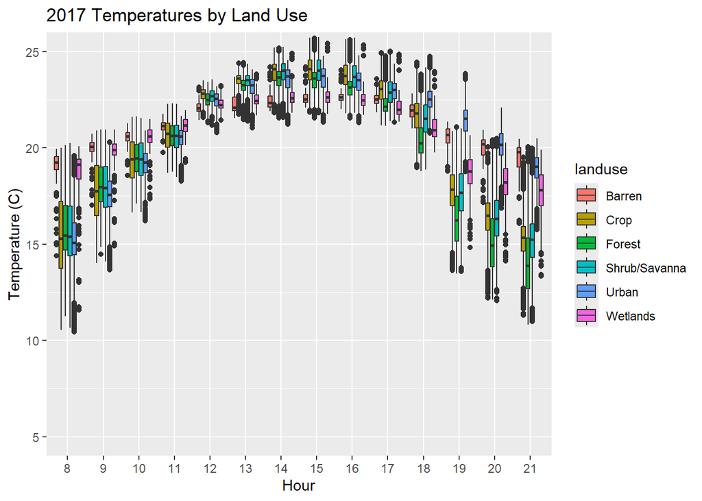

```r
ggplot(HourlyMeans17_wb_lo[c(HourlyMeans17_wb_lo$hour %in% focalHRS),], aes(x=as.factor(hour), y=(T2-273.15), fill=landuse)) +
  geom_boxplot()  + ggtitle("2017 Temperatures by Land Use") +
  xlab("Hour") + ylab("Temperature (C)")  +
   coord_cartesian(ylim = c(5, 25))
```

##humidity

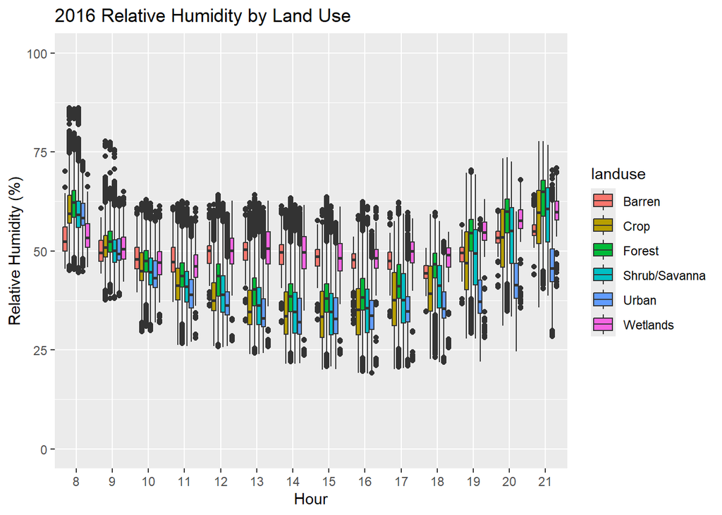

```r
####################Relative Humidity
ggplot(HourlyMeans16_wb_lo[c(HourlyMeans16_wb_lo$hour %in% focalHRS),], aes(x=as.factor(hour), y=rh2, fill=landuse)) +
  geom_boxplot()+ ggtitle("2016 Relative Humidity by Land Use") +
  xlab("Hour") + ylab("Relative Humidity (%)") +
   coord_cartesian(ylim = c(0, 100))
```

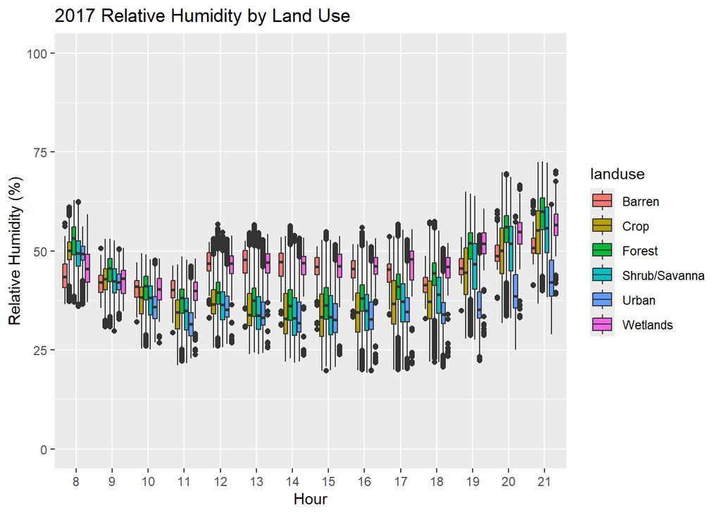

```r
ggplot(HourlyMeans17_wb_lo[c(HourlyMeans17_wb_lo$hour %in% focalHRS),], aes(x=as.factor(hour), y=rh2, fill=landuse)) +
  geom_boxplot() + ggtitle("2017 Relative Humidity by Land Use") +
  xlab("Hour") + ylab("Relative Humidity (%)") +
   coord_cartesian(ylim = c(0, 100))
```

##Look into wind speed

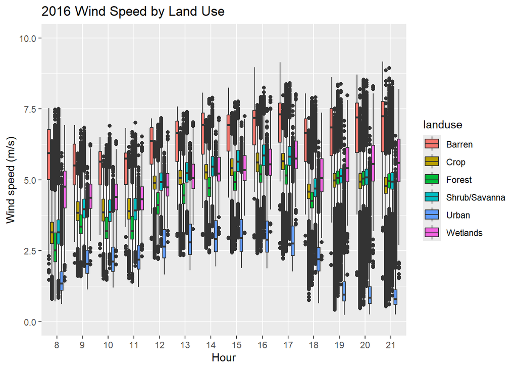

```r
##EDA of wind speed, just to see
ggplot(HourlyMeans16_wb_lo[c(HourlyMeans16_wb_lo$hour %in% focalHRS),], aes(x=as.factor(hour), y=(wspd10), fill=landuse)) +
  geom_boxplot() + ggtitle("2016 Wind Speed by Land Use") +
  xlab("Hour") + ylab("Wind speed (m/s)")  +
   coord_cartesian(ylim = c(0, 10))
```

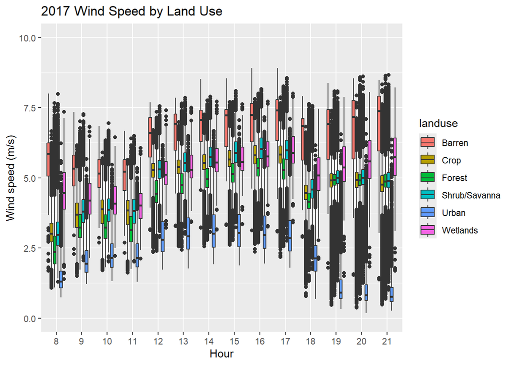

```r
ggplot(HourlyMeans17_wb_lo[c(HourlyMeans17_wb_lo$hour %in% focalHRS),], aes(x=as.factor(hour), y=(wspd10), fill=landuse)) +
  geom_boxplot() + ggtitle("2017 Wind Speed by Land Use") +
  xlab("Hour") + ylab("Wind speed (m/s)")  +
   coord_cartesian(ylim = c(0, 10))
```

##Sea Level pressure

Ideally want to look at pressure differential between ocean and land, can have that as the second set of visuals?

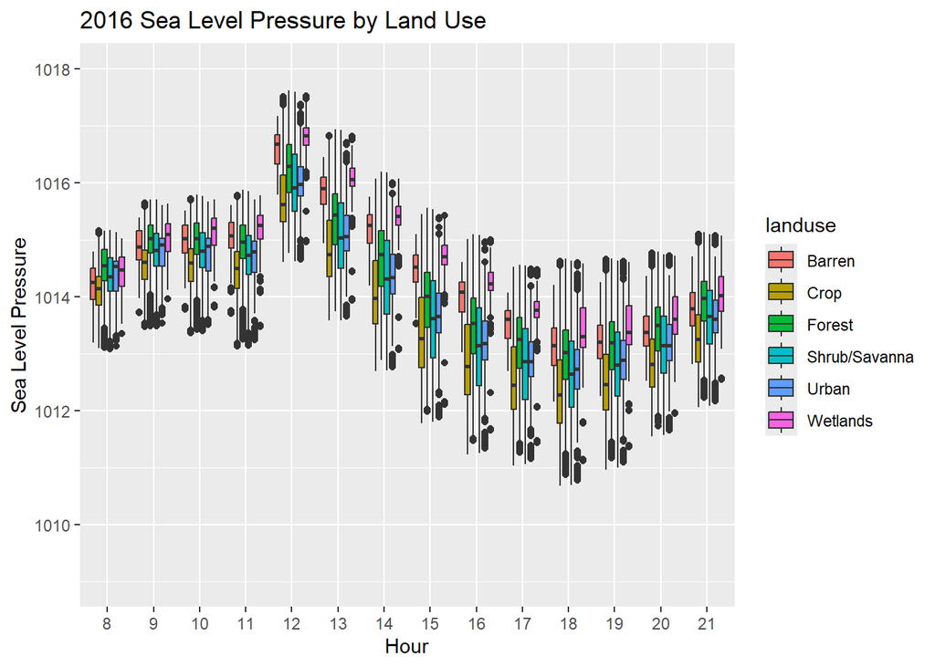

```r
##EDA of slp
ggplot(HourlyMeans16_wb_lo[c(HourlyMeans16_wb_lo$hour %in% focalHRS),], aes(x=as.factor(hour), y=(slp), fill=landuse)) +
  geom_boxplot() + ggtitle("2016 Sea Level Pressure by Land Use") +
  xlab("Hour") + ylab("Sea Level Pressure") +
   coord_cartesian(ylim = c(1009, 1018))
```

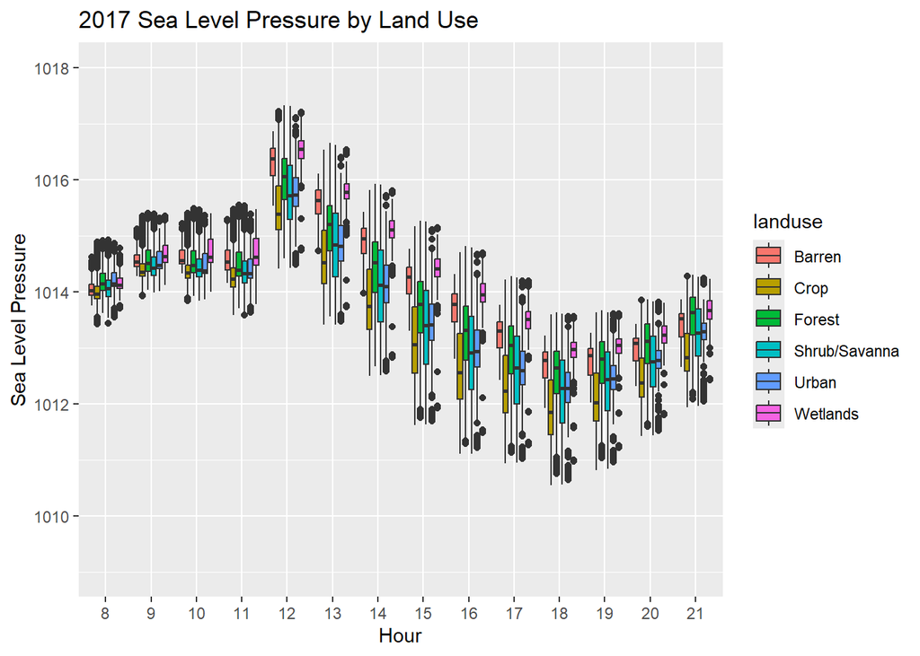

```r
ggplot(HourlyMeans17_wb_lo[c(HourlyMeans17_wb_lo$hour %in% focalHRS),], aes(x=as.factor(hour), y=(slp), fill=landuse)) +
  geom_boxplot() + ggtitle("2017 Sea Level Pressure by Land Use") +
  xlab("Hour") + ylab("Sea Level Pressure")  +
   coord_cartesian(ylim = c(1009, 1018))
```

See if you can compare the ocean to land somehow, Dist2Ocean might be able to help

```r
#Get the ocean cells
OceanCells16 <- HourlyMeans16_wb[HourlyMeans16_wb$Dist2Ocean < 995 & HourlyMeans16_wb$landuse== "Water",] #imperfect but this should be all water adjacent to other ocean pixels
OceanCells17 <- HourlyMeans17_wb[HourlyMeans17_wb$Dist2Ocean < 995 & HourlyMeans17_wb$landuse== "Water",]

Ocean16_meanSLP <- OceanCells16 %>%
  group_by(hour, sim) %>%
  summarize_at(vars(slp), list(meanSLP=mean))

Ocean17_meanSLP <- OceanCells17 %>%
  group_by(hour, sim) %>%
  summarize_at(vars(slp), list(meanSLP=mean))

#should ideally adjust for the scenario in here.....
HourlyMeans16_wb_lo <- HourlyMeans16_wb_lo %>%
  left_join(Ocean16_meanSLP, by = c('hour', 'sim')) %>%
  mutate(slpDiff = slp - meanSLP)

HourlyMeans17_wb_lo <- HourlyMeans17_wb_lo %>%
  left_join(Ocean17_meanSLP, by = "hour") %>%
  mutate(slpDiff = slp - meanSLP)
```

Now visualize the slp difference over time

This is consistent with a reduced land breeze but not a super clear difference in the sea breeze (maybe an ever so slight reduction)

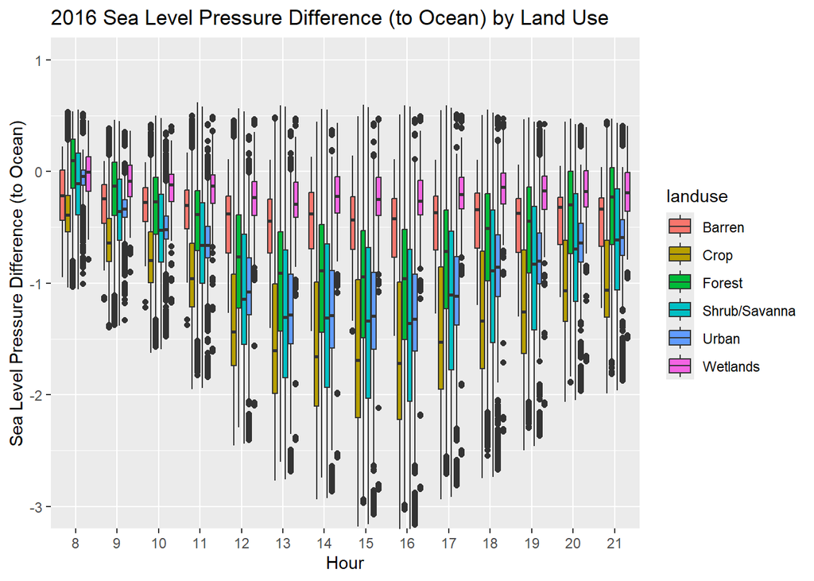

```r
##EDA of wind speed, just to see
ggplot(HourlyMeans16_wb_lo[c(HourlyMeans16_wb_lo$hour %in% focalHRS),], aes(x=as.factor(hour), y=(slpDiff), fill=landuse)) +
  geom_boxplot() + ggtitle("2016 Sea Level Pressure Difference (to Ocean) by Land Use") +
  xlab("Hour") + ylab("Sea Level Pressure Difference (to Ocean)") +
   coord_cartesian(ylim = c(-3, 1))
```

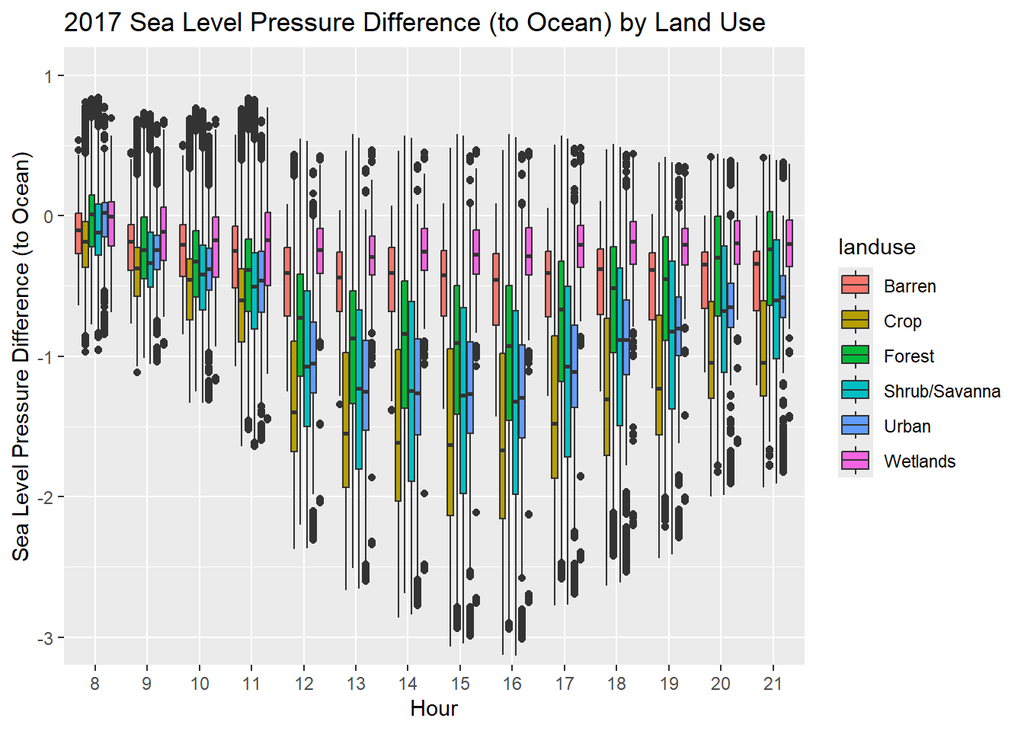

```r
ggplot(HourlyMeans17_wb_lo[c(HourlyMeans17_wb_lo$hour %in% focalHRS),], aes(x=as.factor(hour), y=(slpDiff), fill=landuse)) +
  geom_boxplot() + ggtitle("2017 Sea Level Pressure Difference (to Ocean) by Land Use") +
  xlab("Hour") + ylab("Sea Level Pressure Difference (to Ocean)") +
   coord_cartesian(ylim = c(-3, 1))
```

##Low level Clouds

Noticeably reduced low level clouds in the morning and a bit at night

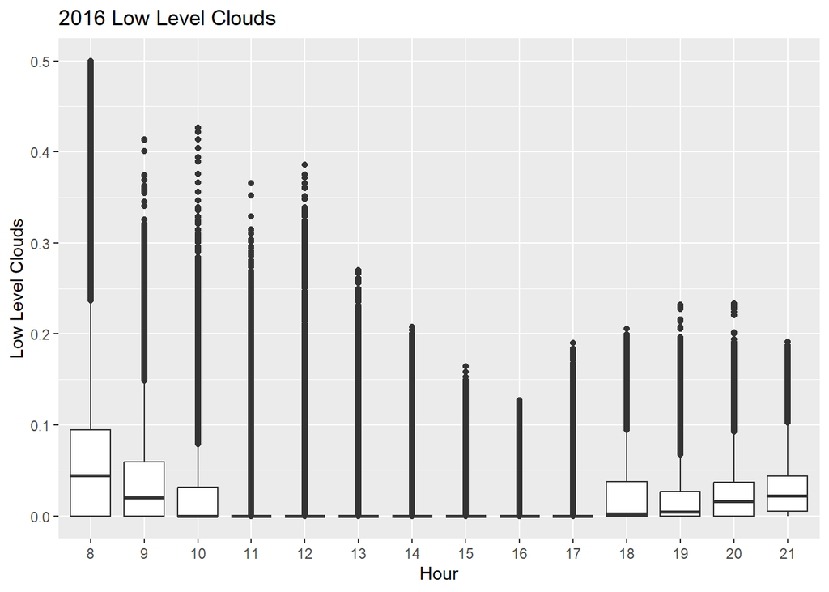

```r
##EDA of wind speed, just to see
ggplot(HourlyMeans16_wb_lo[c(HourlyMeans16_wb_lo$hour %in% focalHRS),], aes(x=as.factor(hour), y=(llc))) +
  geom_boxplot() + ggtitle("2016 Low Level Clouds") +
  xlab("Hour") + ylab("Low Level Clouds") +
   coord_cartesian(ylim = c(0, 0.5))
```

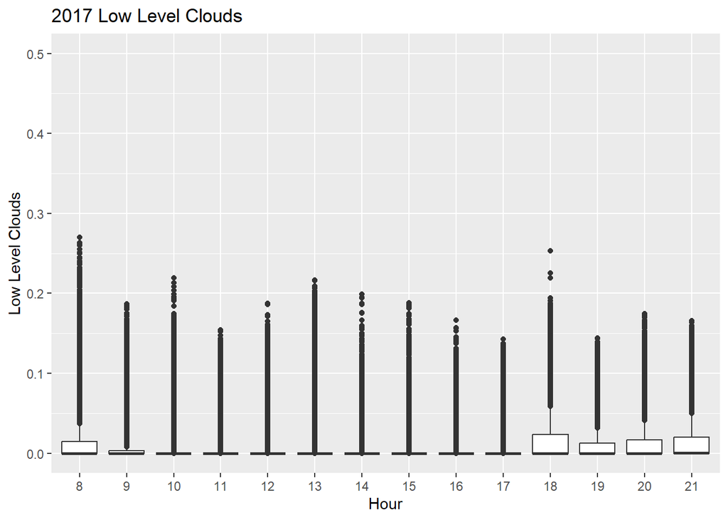

```r
ggplot(HourlyMeans17_wb_lo[c(HourlyMeans17_wb_lo$hour %in% focalHRS),], aes(x=as.factor(hour), y=(llc))) +
  geom_boxplot() + ggtitle("2017 Low Level Clouds") +
  xlab("Hour") + ylab("Low Level Clouds")  +
   coord_cartesian(ylim = c(0, 0.5))
```

#EDA differences between MHW and non-MHW

Just go through and do basic differences by land use/land cover type

Note: since I am averaging, this is very coarse, it reduces all the variation within land use types

```r
#create storage matrix
colNms <- c("Hour", "landuse", "MeanRH16", "MeanRH17",
            "MeanTemp16", "MeanTemp17", "MeanWSp16",
            "MeanWSp17", "MeanSLP16", "MeanSLP17",
            "MeanSLP16Diff", "MeanSLP17Diff", "MeanLLC16", "MeanLLC17")
uLU <- unique(LU_dict$New_Name)
uLUnm <- unique(LU_dict$New_Num)
HourlyMean_byLU <- as.data.frame(matrix(0, ncol=length(colNms), nrow=length(uLU)*24))
names(HourlyMean_byLU) <- colNms

#set up your index for the storage matrix
smat_ind <- 1

for (h in 0:23){

  #get hourly data
  hr16 <- HourlyMeans16_wb_lo[HourlyMeans16_wb_lo$hour == h, ]
  hr17 <- HourlyMeans17_wb_lo[HourlyMeans17_wb_lo$hour == h, ]

  for (l in 1:length(uLUnm)){

    HourlyMean_byLU$Hour[smat_ind] <- h
    HourlyMean_byLU$landuse[smat_ind] <- uLU[l]

    HourlyMean_byLU$MeanRH16[smat_ind] <- mean(hr16$rh2[hr16$landuse == uLU[l]])
    HourlyMean_byLU$MeanRH17[smat_ind] <- mean(hr17$rh2[hr17$landuse == uLU[l]])

    HourlyMean_byLU$MeanTemp16[smat_ind] <- mean(hr16$T2[hr16$landuse == uLU[l]])
    HourlyMean_byLU$MeanTemp17[smat_ind] <- mean(hr17$T2[hr17$landuse == uLU[l]])

    HourlyMean_byLU$MeanWSp16[smat_ind] <- mean(hr16$wspd10[hr16$landuse == uLU[l]])
    HourlyMean_byLU$MeanWSp17[smat_ind] <- mean(hr17$wspd10[hr17$landuse == uLU[l]])

    HourlyMean_byLU$MeanSLP16[smat_ind] <- mean(hr16$slp[hr16$landuse == uLU[l]])
    HourlyMean_byLU$MeanSLP17[smat_ind] <- mean(hr17$slp[hr17$landuse == uLU[l]])

    HourlyMean_byLU$MeanSLP16Diff[smat_ind] <- mean(hr16$slpDiff[hr16$landuse == uLU[l]])
    HourlyMean_byLU$MeanSLP17Diff[smat_ind] <- mean(hr17$slpDiff[hr17$landuse == uLU[l]])

    HourlyMean_byLU$MeanLLC16[smat_ind] <- mean(hr16$llc[hr16$landuse == uLU[l]])
    HourlyMean_byLU$MeanLLC17[smat_ind] <- mean(hr17$llc[hr17$landuse == uLU[l]])

    #increase the iteration
    smat_ind <- smat_ind + 1
  }

}

#get rid of LU with no data
HourlyMean_byLU <- HourlyMean_byLU[!is.na(HourlyMean_byLU$MeanTemp16),]

#calculate your differences
HourlyMean_byLU$DiffRH <- HourlyMean_byLU$MeanRH17 - HourlyMean_byLU$MeanRH16
HourlyMean_byLU$DiffTemp <- HourlyMean_byLU$MeanTemp17 - HourlyMean_byLU$MeanTemp16
HourlyMean_byLU$DiffWS <- HourlyMean_byLU$MeanWSp17 - HourlyMean_byLU$MeanWSp16
HourlyMean_byLU$DiffSLP <- HourlyMean_byLU$MeanSLP17 - HourlyMean_byLU$MeanSLP16
HourlyMean_byLU$DiffoDiffSLP <- HourlyMean_byLU$MeanSLP17Diff - HourlyMean_byLU$MeanSLP16Diff
HourlyMean_byLU$DiffLLC <- HourlyMean_byLU$MeanLLC17 - HourlyMean_byLU$MeanLLC16
```

Now plot out our results so we can look at it a bit more clearly

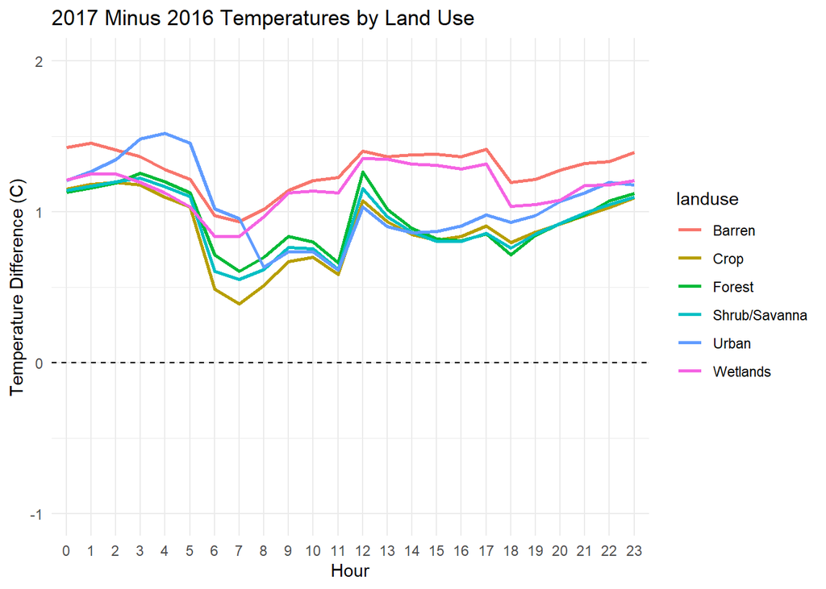

```r
###difference plots
ggplot(HourlyMean_byLU, aes(x=as.factor(Hour), y=(DiffTemp), group=landuse)) +
  geom_line(aes(color=landuse), size=1) + ggtitle("2017 Minus 2016 Temperatures by Land Use") +
  xlab("Hour") + ylab("Temperature Difference (C)")  + geom_hline(yintercept=0, linetype="dashed") +
   coord_cartesian(ylim = c(-1, 2)) + theme_minimal()
```

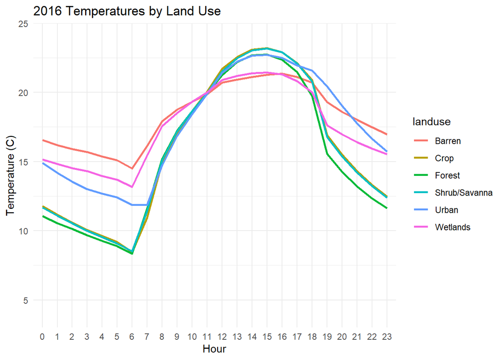

```r
####Simple figures to make sure the individual averages over time are reasonable

ggplot(HourlyMean_byLU, aes(x=as.factor(Hour), y=(MeanTemp16-273.15), group=landuse)) +
  geom_line(aes(color=landuse), size=1) + ggtitle("2016 Temperatures by Land Use") +
  xlab("Hour") + ylab("Temperature (C)") +
   coord_cartesian(ylim = c(4, 24)) + theme_minimal()
```

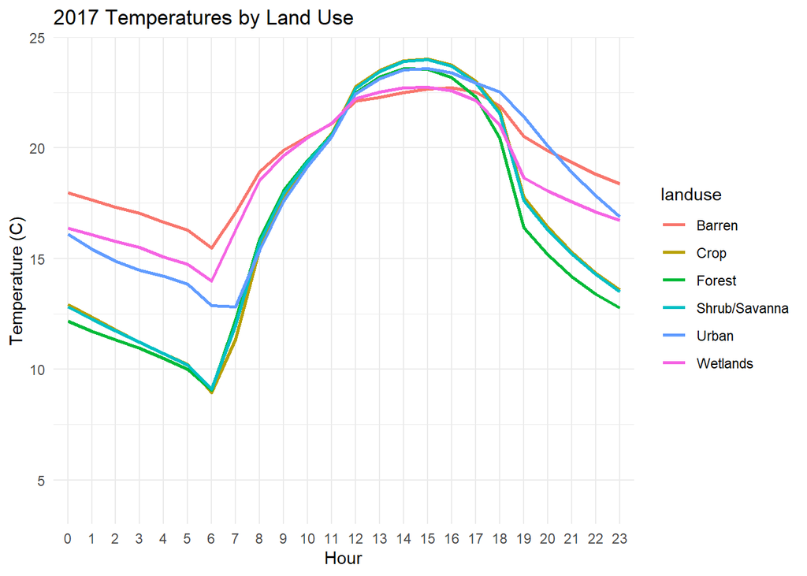

```r
ggplot(HourlyMean_byLU, aes(x=as.factor(Hour), y=(MeanTemp17-273.15), group=landuse)) +
  geom_line(aes(color=landuse), size=1) + ggtitle("2017 Temperatures by Land Use") +
  xlab("Hour") + ylab("Temperature (C)") +
   coord_cartesian(ylim = c(4, 24)) + theme_minimal()
```

Now for relative humidity

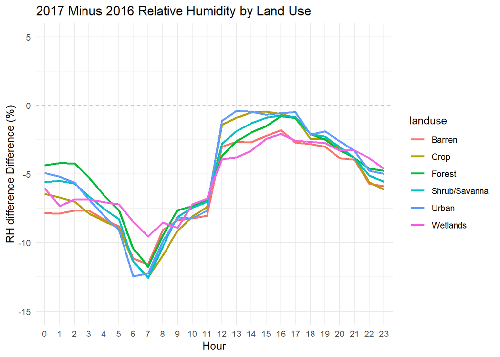

```r
##difference plots
ggplot(HourlyMean_byLU, aes(x=as.factor(Hour), y=(DiffRH), group=landuse)) +
  geom_line(aes(color=landuse), size=1) + ggtitle("2017 Minus 2016 Relative Humidity by Land Use") +
  xlab("Hour") + ylab("RH difference Difference (%)")  + geom_hline(yintercept=0, linetype="dashed") +
   coord_cartesian(ylim = c(-15, 5))+ theme_minimal()
```

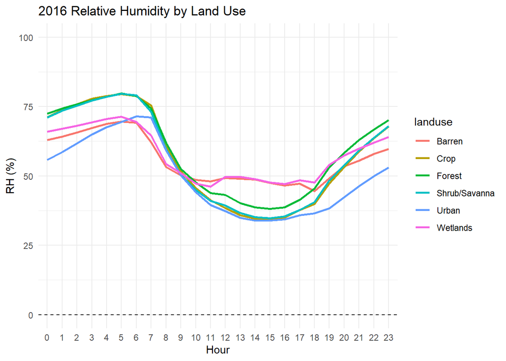

```r
###individual plots for each year to make sure they are reasonable
ggplot(HourlyMean_byLU, aes(x=as.factor(Hour), y=(MeanRH16), group=landuse)) +
  geom_line(aes(color=landuse), size=1) + ggtitle("2016 Relative Humidity by Land Use") +
  xlab("Hour") + ylab("RH (%)") + geom_hline(yintercept=0, linetype="dashed")  +
   coord_cartesian(ylim = c(0, 100))+ theme_minimal()
```

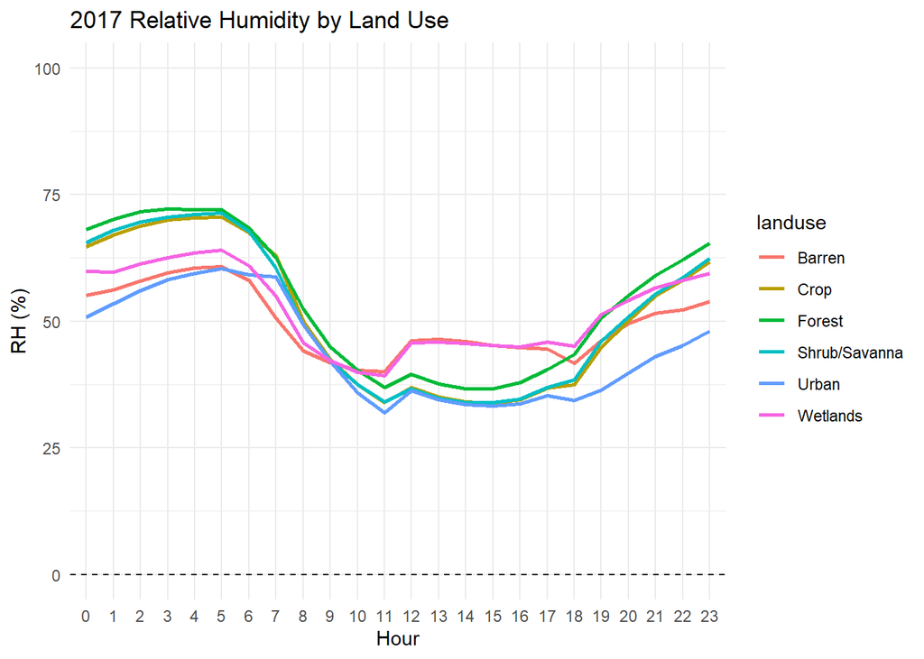

```r
ggplot(HourlyMean_byLU, aes(x=as.factor(Hour), y=(MeanRH17), group=landuse)) +
  geom_line(aes(color=landuse), size=1) + ggtitle("2017 Relative Humidity by Land Use") +
  xlab("Hour") + ylab("RH (%)") + geom_hline(yintercept=0, linetype="dashed")  +
   coord_cartesian(ylim = c(0, 100))+ theme_minimal()
```

Now for wind speed

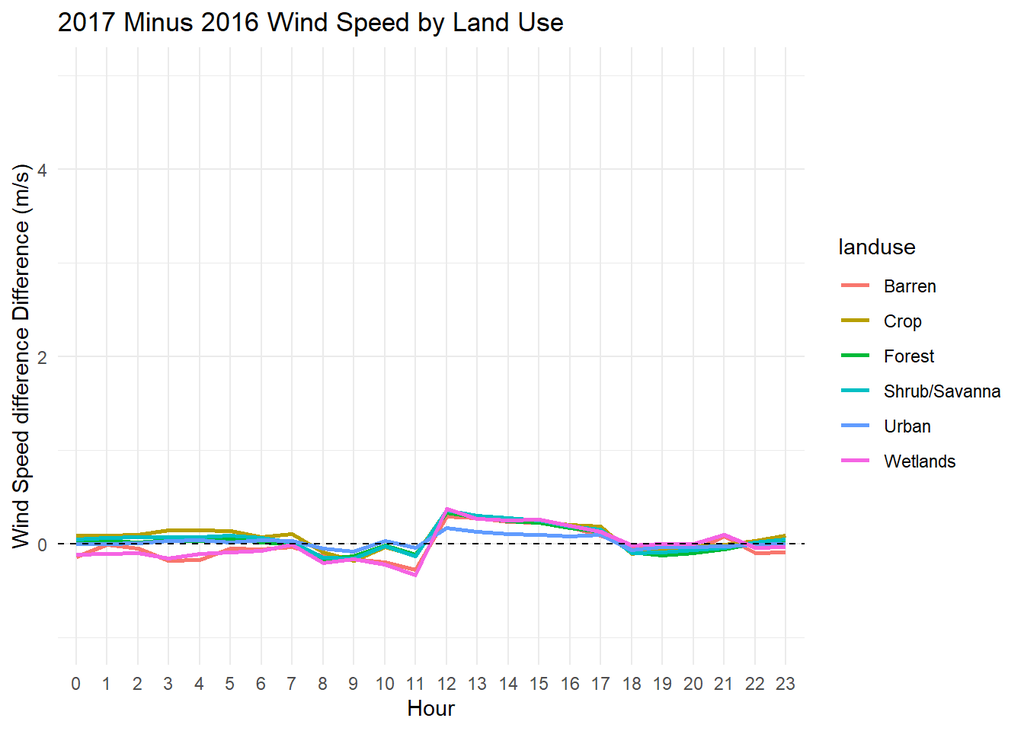

```r
#difference plots
ggplot(HourlyMean_byLU, aes(x=as.factor(Hour), y=(DiffWS), group=landuse)) +
  geom_line(aes(color=landuse), linewidth=1) + ggtitle("2017 Minus 2016 Wind Speed by Land Use") +
  xlab("Hour") + ylab("Wind Speed difference Difference (m/s)")  + geom_hline(yintercept=0, linetype="dashed") +
   coord_cartesian(ylim = c(-1, 5))+ theme_minimal()
```

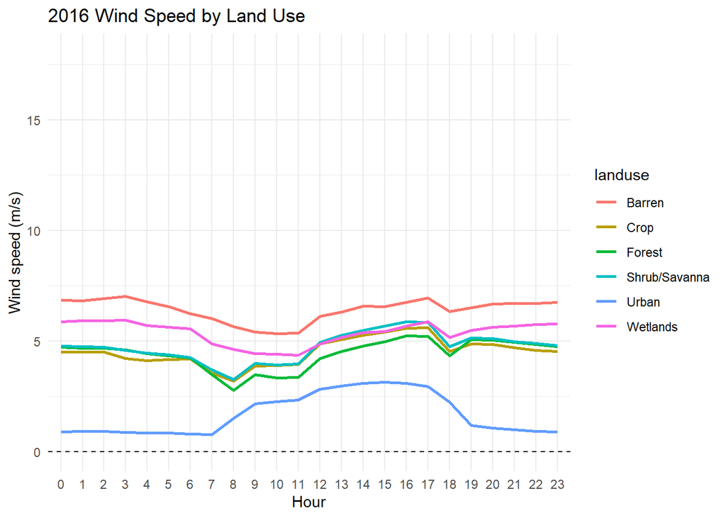

```r
###individual plots for each year to make sure they make sense
ggplot(HourlyMean_byLU, aes(x=as.factor(Hour), y=(MeanWSp16), group=landuse)) +
  geom_line(aes(color=landuse), linewidth=1) + ggtitle("2016 Wind Speed by Land Use") +
  xlab("Hour") + ylab("Wind speed (m/s)") + geom_hline(yintercept=0, linetype="dashed") +
   coord_cartesian(ylim = c(0, 18))+ theme_minimal()
```

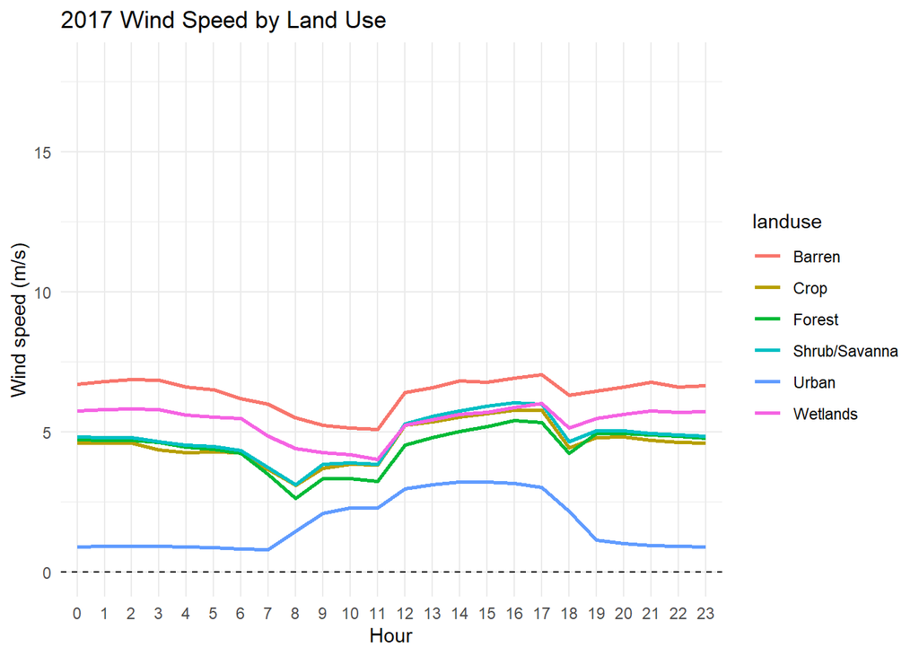

```r
ggplot(HourlyMean_byLU, aes(x=as.factor(Hour), y=(MeanWSp17), group=landuse)) +
  geom_line(aes(color=landuse), linewidth=1) + ggtitle("2017 Wind Speed by Land Use") +
  xlab("Hour") + ylab("Wind speed (m/s)") + geom_hline(yintercept=0, linetype="dashed") +
   coord_cartesian(ylim = c(0, 18))+ theme_minimal()
```

##Sea Level Pressure Difference

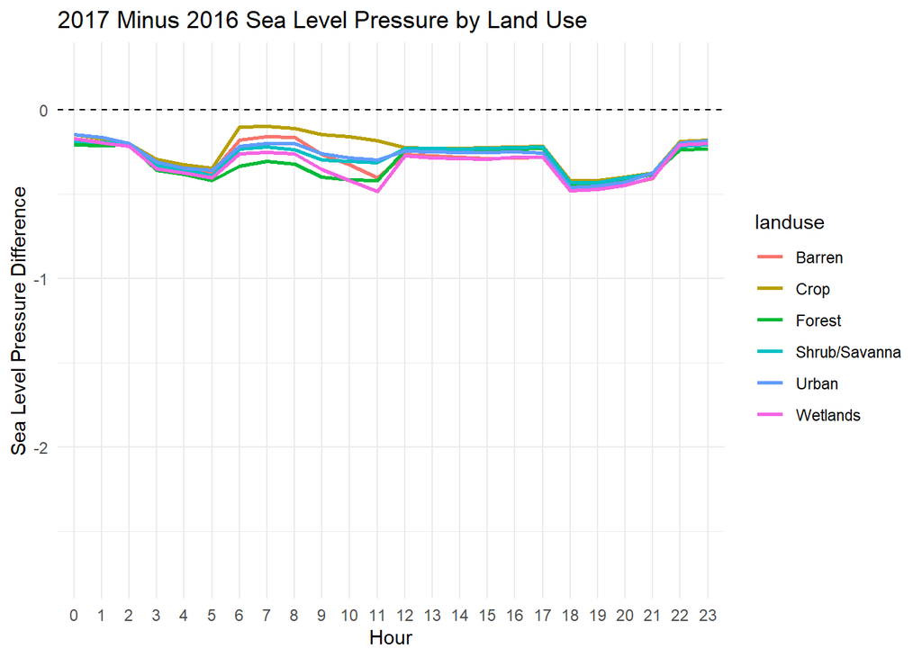

```r
#difference plots
ggplot(HourlyMean_byLU, aes(x=as.factor(Hour), y=(DiffSLP), group=landuse)) +
  geom_line(aes(color=landuse), linewidth=1) + ggtitle("2017 Minus 2016 Sea Level Pressure by Land Use") +
  xlab("Hour") + ylab("Sea Level Pressure Difference")  + geom_hline(yintercept=0, linetype="dashed") +
   coord_cartesian(ylim = c(-2.75, 0.25))+ theme_minimal()
```

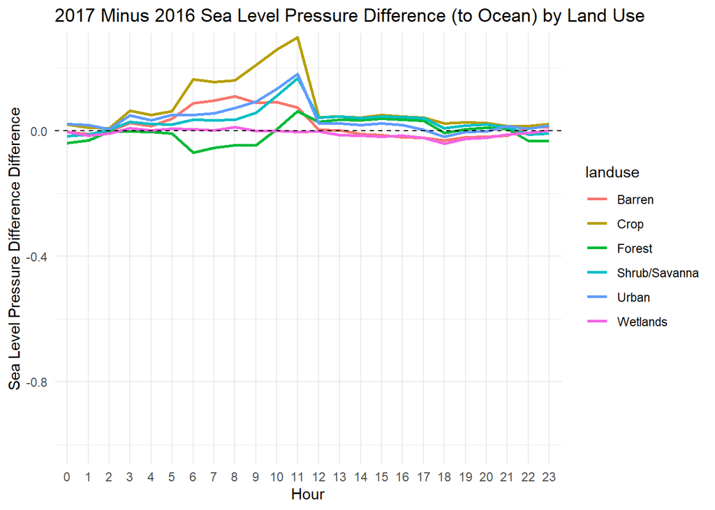

```r
## Plots of the Difference in Difference
ggplot(HourlyMean_byLU, aes(x=as.factor(Hour), y=(DiffoDiffSLP), group=landuse)) +
  geom_line(aes(color=landuse), linewidth=1) + ggtitle("2017 Minus 2016 Sea Level Pressure Difference (to Ocean) by Land Use") +
  xlab("Hour") + ylab("Sea Level Pressure Difference Difference")  + geom_hline(yintercept=0, linetype="dashed") +
   coord_cartesian(ylim = c(-1, 0.25))+ theme_minimal()
```

## Low-level Clouds

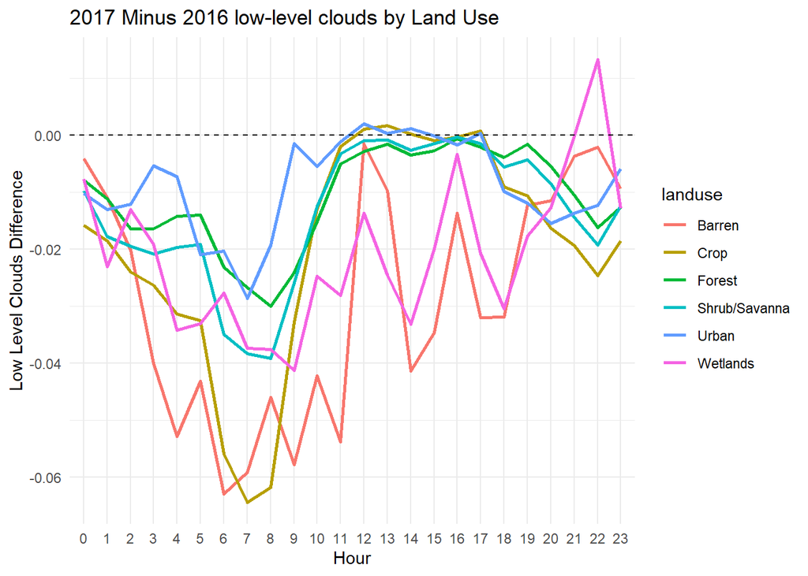

```r
ggplot(HourlyMean_byLU, aes(x=as.factor(Hour), y=(DiffLLC), group=landuse)) +
  geom_line(aes(color=landuse), linewidth=1) + ggtitle("2017 Minus 2016 low-level clouds by Land Use") +
  xlab("Hour") + ylab("Low Level Clouds Difference")  + geom_hline(yintercept=0, linetype="dashed") + theme_minimal()
```

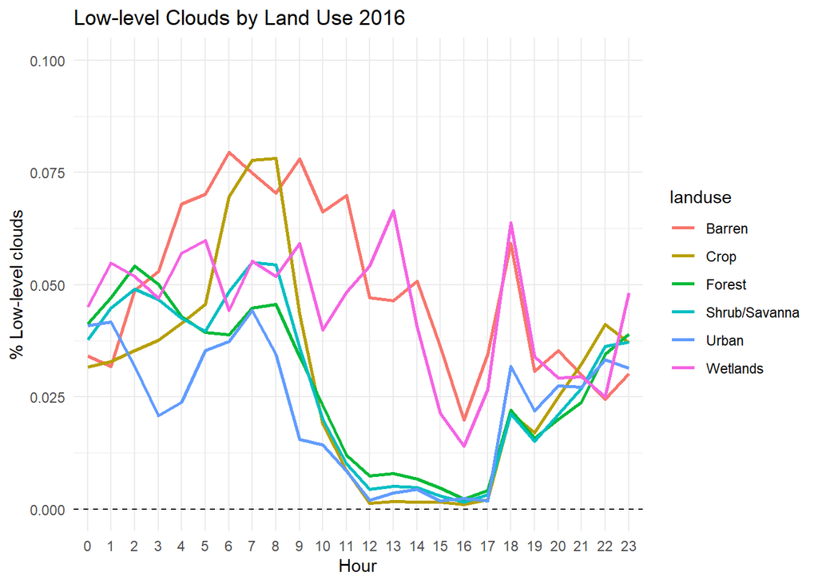

```r
#Plots for each year for reference
ggplot(HourlyMean_byLU, aes(x=as.factor(Hour), y=(MeanLLC16), group=landuse)) +
  geom_line(aes(color=landuse), linewidth=1) + ggtitle("Low-level Clouds by Land Use 2016") +
  xlab("Hour") + ylab("% Low-level clouds") + geom_hline(yintercept=0, linetype="dashed") +
   coord_cartesian(ylim = c(0, 0.1))+ theme_minimal()
```

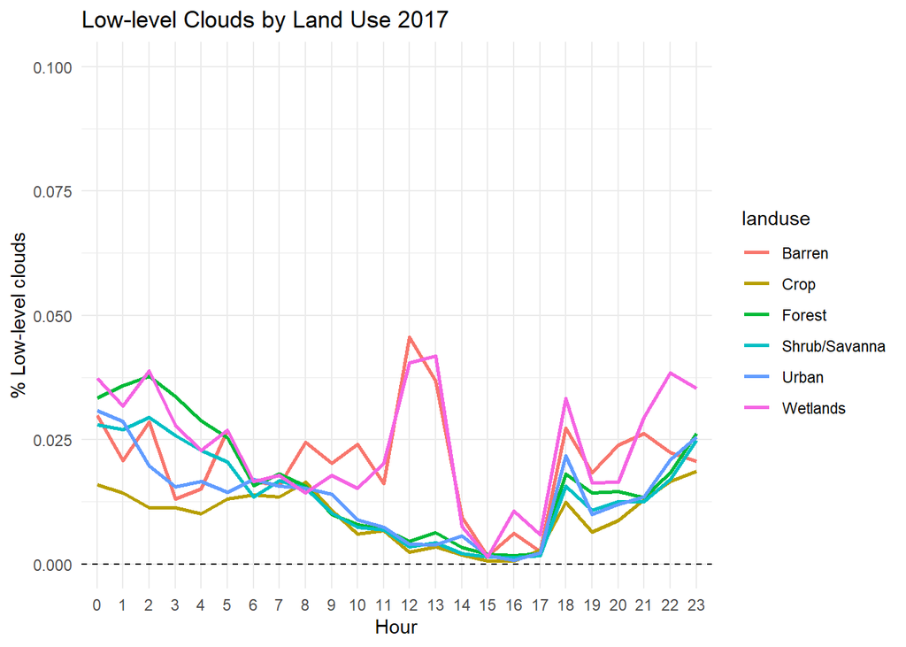

```r
ggplot(HourlyMean_byLU, aes(x=as.factor(Hour), y=(MeanLLC17), group=landuse)) +
  geom_line(aes(color=landuse), linewidth=1) + ggtitle("Low-level Clouds by Land Use 2017") +
  xlab("Hour") + ylab("% Low-level clouds") + geom_hline(yintercept=0, linetype="dashed") +
   coord_cartesian(ylim = c(0, 0.1))+ theme_minimal()
```